# Synthesis Exercise: Microarray Data Analysis

Guillem Cortiada Rovira

4/6/2020

## Introduction

All codes will be available in my GitHub: https://github.com/guillem99/Omics_techniques_2020.git

## Title

Topical protein tyrosine kinase inhibitor effect on graft model of alopecia areata: time course

# Summary

Analysis of skin from C3H/HeJ grafted recipients with established alopecia areata (AA) following alopecic graft transplantation that were treated with topical Janus kinase (JAK) inhibitor ruxolitinib or tofacitinib for up to 24 wks. Results provide insight into molecular basis of AA pathogenesis.

# Objective

The aim of the study is the genes expressions patterns after an alopecic graft transplant.

## Information on the Experimental Design

# Experiment Design

We have three groups of mouse that after an alopecic graft transplantation skin his skin were taken at initial time, 6, 12 and 24 weeks (in 24 weeks, we only have taken the 2 groups with treatment and only two samples in each one) after administration of ruxolitinib(jak1i), tofacitinib(jak3i) or reference substance role. It is a group design (Expression profiling by array)

# Response Variable

Gene expression patterns

# Groups

3 groups (reference, treated with tofacitinib(jak3i), treated with ruxolitinib(jak1i)) (3 biological replicates were taken at each time point for each treatment modality)

·Sample Size = 31 samples: 3 assays: initial time point, reference substance role 3 assays: initial time point, tofacitinib 3 assays: initial time point, ruxolitinib 3 assays: 6 weeks, reference substance role 3 assays: 6 weeks, tofacitinib 3 assays: 6 weeks, ruxolitinib 3 assays: 12 weeks, reference substance role 3 assays: 12 weeks, tofacitinib 3 assays: 12 weeks, ruxolitinib 2 assays: 24 weeks, tofacitinib 2 assays: 24 weeks, ruxolitinib - In 0, 6 and 12 weeks = (3(reference)+3(tofacitinib)+3(ruxolitinib))*3 = 27 - In 24 weeks only 2(tofacitinib)+2(ruxolitinib)

·Experimental Factors: Batch = (Block) Scan date Treatment = (treatment) Vehicle (PBS), tofacitinib, ruxolitinib Timepoint = (timepoint) 0 weeks, 6 weeks, 12 weeks, 24 weeks

# Organism

Mus Musculus

# Platform

GPL1261: Affymetrix Mouse Genome 430 2.0 Array

# Citations

Xing L, Dai Z, Jabbari A, Cerise JE et al. Alopecia areata is driven by cytotoxic T lymphocytes and is reversed by JAK inhibition. Nat Med 2014 Sep;20(9):1043-9. PMID: 25129481

# GEO Dataset

```r
gse <- getGEO("GSE45514", GSEMatrix = TRUE)
```

```
## Found 1 file(s)
```

```
## GSE45514_series_matrix.txt.gz
```

```
## File stored at:
```

```
## C:\Users\guill\AppData\Local\Temp\Rtmpcnm19a/GPL1261.soft
```

```r
summary(gse)
```

```
##                               Length Class         Mode
## GSE45514_series_matrix.txt.gz 1      ExpressionSet S4
```

# Description of the data

```r
show(gse)
```

```
## $GSE45514_series_matrix.txt.gz
## ExpressionSet (storageMode: lockedEnvironment)
## assayData: 45101 features, 31 samples
##   element names: exprs
## protocolData: none
## phenoData
##   sampleNames: GSM1105885 GSM1105886 ... GSM1105915 (31 total)
##   varLabels: title geo_accession ... treatment:ch1 (35 total)
##   varMetadata: labelDescription
## featureData
##   featureNames: 1415670_at 1415671_at ... AFFX-TrpnX-M_at (45101 total)
##   fvarLabels: ID GB_ACC ... Gene Ontology Molecular Function (16 total)
##   fvarMetadata: Column Description labelDescription
## experimentData: use 'experimentData(object)'
##   pubMedIds: 25129481
## Annotation: GPL1261
```

```r
class(gse)
```

```
## [1] "list"
```

```r
names(gse)
```

```
## [1] "GSE45514_series_matrix.txt.gz"
```

```r
eset <- gse[[1]]
print("esetFromGeo")
```

```
## [1] "esetFromGeo"
```

```r
eset
```

```
## ExpressionSet (storageMode: lockedEnvironment)
## assayData: 45101 features, 31 samples
##   element names: exprs
## protocolData: none
## phenoData
##   sampleNames: GSM1105885 GSM1105886 ... GSM1105915 (31 total)
##   varLabels: title geo_accession ... treatment:ch1 (35 total)
##   varMetadata: labelDescription
## featureData
##   featureNames: 1415670_at 1415671_at ... AFFX-TrpnX-M_at (45101 total)
##   fvarLabels: ID GB_ACC ... Gene Ontology Molecular Function (16 total)
##   fvarMetadata: Column Description labelDescription
## experimentData: use 'experimentData(object)'
##   pubMedIds: 25129481
## Annotation: GPL1261
```

```r
targets <- pData(eset)
print("Targets")
```

```
## [1] "Targets"
```

```r
head(targets)
```

```
##                   title geo_accession                status submission_date
## GSM1105885 skin-J1-0W-1    GSM1105885 Public on Aug 17 2014     Mar 26 2013
## GSM1105886 skin-J1-0W-2    GSM1105886 Public on Aug 17 2014     Mar 26 2013
## GSM1105887 skin-J1-0W-3    GSM1105887 Public on Aug 17 2014     Mar 26 2013
## GSM1105888 skin-J1-6W-1    GSM1105888 Public on Aug 17 2014     Mar 26 2013
## GSM1105889 skin-J1-6W-2    GSM1105889 Public on Aug 17 2014     Mar 26 2013
## GSM1105890 skin-J1-6W-3    GSM1105890 Public on Aug 17 2014     Mar 26 2013
##            last_update_date type channel_count source_name_ch1 organism_ch1
## GSM1105885      Aug 17 2014  RNA             1    skin-J1-0W-1 Mus musculus
## GSM1105886      Aug 17 2014  RNA             1    skin-J1-0W-2 Mus musculus
## GSM1105887      Aug 17 2014  RNA             1    skin-J1-0W-3 Mus musculus
## GSM1105888      Aug 17 2014  RNA             1    skin-J1-6W-1 Mus musculus
## GSM1105889      Aug 17 2014  RNA             1    skin-J1-6W-2 Mus musculus
## GSM1105890      Aug 17 2014  RNA             1    skin-J1-6W-3 Mus musculus
##            characteristics_ch1 characteristics_ch1.1 characteristics_ch1.2
## GSM1105885     strain: C3H/HeJ          tissue: skin      treatment: jak1i
## GSM1105886     strain: C3H/HeJ          tissue: skin      treatment: jak1i
## GSM1105887     strain: C3H/HeJ          tissue: skin      treatment: jak1i
## GSM1105888     strain: C3H/HeJ          tissue: skin      treatment: jak1i
## GSM1105889     strain: C3H/HeJ          tissue: skin      treatment: jak1i
## GSM1105890     strain: C3H/HeJ          tissue: skin      treatment: jak1i
##            characteristics_ch1.3 molecule_ch1
## GSM1105885     treatment time: 0    total RNA
## GSM1105886     treatment time: 0    total RNA
## GSM1105887     treatment time: 0    total RNA
## GSM1105888     treatment time: 6    total RNA
## GSM1105889     treatment time: 6    total RNA
## GSM1105890     treatment time: 6    total RNA
##                                      extract_protocol_ch1 label_ch1
## GSM1105885 Qiagen miRNeasy with on-column DNase digestion    biotin
## GSM1105886 Qiagen miRNeasy with on-column DNase digestion    biotin
## GSM1105887 Qiagen miRNeasy with on-column DNase digestion    biotin
## GSM1105888 Qiagen miRNeasy with on-column DNase digestion    biotin
## GSM1105889 Qiagen miRNeasy with on-column DNase digestion    biotin
## GSM1105890 Qiagen miRNeasy with on-column DNase digestion    biotin
##                        label_protocol_ch1 taxid_ch1
## GSM1105885 3' IVT Express Kit, Affymetrix     10090
## GSM1105886 3' IVT Express Kit, Affymetrix     10090
## GSM1105887 3' IVT Express Kit, Affymetrix     10090
## GSM1105888 3' IVT Express Kit, Affymetrix     10090
```

[output cut: 50 more lines]

```
## GSM1105890 ftp://ftp.ncbi.nlm.nih.gov/geo/samples/GSM1105nnn/GSM1105890/suppl/GSM1105890_J1-6W-3.CEL.gz
##            data_row_count strain:ch1 tissue:ch1 treatment time:ch1
## GSM1105885          45101    C3H/HeJ       skin                  0
## GSM1105886          45101    C3H/HeJ       skin                  0
## GSM1105887          45101    C3H/HeJ       skin                  0
## GSM1105888          45101    C3H/HeJ       skin                  6
## GSM1105889          45101    C3H/HeJ       skin                  6
## GSM1105890          45101    C3H/HeJ       skin                  6
##            treatment:ch1
## GSM1105885         jak1i
## GSM1105886         jak1i
## GSM1105887         jak1i
## GSM1105888         jak1i
## GSM1105889         jak1i
## GSM1105890         jak1i
```

Maximum, minimum and mean for each group (Jak1i, Jak3i and PBS)

```r
eset_jak1i <- exprs(eset[,1:11])
eset_jak3i <- exprs(eset[,12:22])
eset_pbs <- exprs(eset[,23:31])

# Jak1i
print(paste("Minimum = ", min(eset_jak1i) ))
```

```
## [1] "Minimum =  2.62378014"
```

```r
print(paste("Maximum = ", max(eset_jak1i) ))
```

```
## [1] "Maximum =  14.56607766"
```

```r
print(paste("Mean = ", mean(eset_jak1i)))
```

```
## [1] "Mean =  6.53308456470713"
```

```r
# Jak3i
print(paste("Minimum = ", min(eset_jak3i)))
```

```
## [1] "Minimum =  2.631121305"
```

```r
print(paste("Maximum = ", max(eset_jak3i)))
```

```
## [1] "Maximum =  14.54877619"
```

```r
print(paste("Mean = ", mean(eset_jak3i)))
```

```
## [1] "Mean =  6.52635676294708"
```

```r
# PBS
print(paste("Minimum = ", min(eset_pbs)))
```

```
## [1] "Minimum =  2.594909295"
```

```r
print(paste("Maximum = ", max(eset_pbs)))
```

```
## [1] "Maximum =  14.68982884"
```

```r
print(paste("Mean = ", mean(eset_pbs)))
```

```
## [1] "Mean =  6.52910862993678"
```

```r
print("ExpressionSet")
```

```
## [1] "ExpressionSet"
```

```r
gene_expresion <- exprs(eset)

print(paste("Number of genes and number of samples = ", dim(gene_expresion)))
```

```
## [1] "Number of genes and number of samples =  45101"
## [2] "Number of genes and number of samples =  31"
```

```r
summary(gene_expresion)
```

```
##    GSM1105885       GSM1105886       GSM1105887       GSM1105888
##  Min.   : 2.735   Min.   : 2.673   Min.   : 2.680   Min.   : 2.624
##  1st Qu.: 4.613   1st Qu.: 4.647   1st Qu.: 4.585   1st Qu.: 4.605
##  Median : 6.155   Median : 6.189   Median : 6.147   Median : 6.170
##  Mean   : 6.526   Mean   : 6.549   Mean   : 6.520   Mean   : 6.526
##  3rd Qu.: 8.152   3rd Qu.: 8.172   3rd Qu.: 8.176   3rd Qu.: 8.174
##  Max.   :14.506   Max.   :14.566   Max.   :14.458   Max.   :14.428
##    GSM1105889       GSM1105890       GSM1105891       GSM1105892
##  Min.   : 2.667   Min.   : 2.641   Min.   : 2.681   Min.   : 2.741
##  1st Qu.: 4.627   1st Qu.: 4.609   1st Qu.: 4.521   1st Qu.: 4.564
##  Median : 6.175   Median : 6.215   Median : 6.234   Median : 6.219
##  Mean   : 6.526   Mean   : 6.544   Mean   : 6.540   Mean   : 6.540
##  3rd Qu.: 8.144   3rd Qu.: 8.196   3rd Qu.: 8.263   3rd Qu.: 8.224
##  Max.   :14.499   Max.   :14.444   Max.   :14.454   Max.   :14.436
##    GSM1105893       GSM1105894       GSM1105895       GSM1105896
##  Min.   : 2.667   Min.   : 2.670   Min.   : 2.642   Min.   : 2.679
##  1st Qu.: 4.570   1st Qu.: 4.559   1st Qu.: 4.561   1st Qu.: 4.543
##  Median : 6.159   Median : 6.205   Median : 6.164   Median : 6.179
##  Mean   : 6.528   Mean   : 6.537   Mean   : 6.529   Mean   : 6.521
##  3rd Qu.: 8.217   3rd Qu.: 8.225   3rd Qu.: 8.240   3rd Qu.: 8.212
##  Max.   :14.445   Max.   :14.441   Max.   :14.467   Max.   :14.438
##    GSM1105897       GSM1105898       GSM1105899       GSM1105900
##  Min.   : 2.705   Min.   : 2.685   Min.   : 2.666   Min.   : 2.631
##  1st Qu.: 4.598   1st Qu.: 4.640   1st Qu.: 4.589   1st Qu.: 4.562
##  Median : 6.055   Median : 6.172   Median : 6.161   Median : 6.235
##  Mean   : 6.489   Mean   : 6.533   Mean   : 6.520   Mean   : 6.539
##  3rd Qu.: 8.111   3rd Qu.: 8.155   3rd Qu.: 8.163   3rd Qu.: 8.215
##  Max.   :14.468   Max.   :14.441   Max.   :14.451   Max.   :14.433
##    GSM1105901       GSM1105902       GSM1105903       GSM1105904
##  Min.   : 2.687   Min.   : 2.690   Min.   : 2.686   Min.   : 2.691
##  1st Qu.: 4.648   1st Qu.: 4.510   1st Qu.: 4.549   1st Qu.: 4.498
##  Median : 6.169   Median : 6.226   Median : 6.205   Median : 6.197
##  Mean   : 6.537   Mean   : 6.535   Mean   : 6.538   Mean   : 6.528
##  3rd Qu.: 8.160   3rd Qu.: 8.277   3rd Qu.: 8.247   3rd Qu.: 8.282
##  Max.   :14.549   Max.   :14.423   Max.   :14.486   Max.   :14.496
##    GSM1105905       GSM1105906       GSM1105907       GSM1105908
##  Min.   : 2.696   Min.   : 2.699   Min.   : 2.657   Min.   : 2.690
##  1st Qu.: 4.548   1st Qu.: 4.554   1st Qu.: 4.619   1st Qu.: 4.594
##  Median : 6.142   Median : 6.142   Median : 6.123   Median : 6.175
##  Mean   : 6.525   Mean   : 6.524   Mean   : 6.508   Mean   : 6.528
##  3rd Qu.: 8.241   3rd Qu.: 8.245   3rd Qu.: 8.116   3rd Qu.: 8.164
##  Max.   :14.402   Max.   :14.447   Max.   :14.414   Max.   :14.690
##    GSM1105909       GSM1105910       GSM1105911       GSM1105912
##  Min.   : 2.708   Min.   : 2.690   Min.   : 2.595   Min.   : 2.642
##  1st Qu.: 4.590   1st Qu.: 4.542   1st Qu.: 4.606   1st Qu.: 4.584
##  Median : 6.195   Median : 6.241   Median : 6.200   Median : 6.231
##  Mean   : 6.536   Mean   : 6.538   Mean   : 6.529   Mean   : 6.542
##  3rd Qu.: 8.197   3rd Qu.: 8.233   3rd Qu.: 8.146   3rd Qu.: 8.202
##  Max.   :14.607   Max.   :14.440   Max.   :14.431   Max.   :14.437
##    GSM1105913       GSM1105914       GSM1105915
##  Min.   : 2.747   Min.   : 2.679   Min.   : 2.690
##  1st Qu.: 4.594   1st Qu.: 4.530   1st Qu.: 4.605
##  Median : 6.219   Median : 6.197   Median : 6.050
##  Mean   : 6.550   Mean   : 6.527   Mean   : 6.503
##  3rd Qu.: 8.206   3rd Qu.: 8.243   3rd Qu.: 8.161
##  Max.   :14.468   Max.   :14.428   Max.   :14.516
```

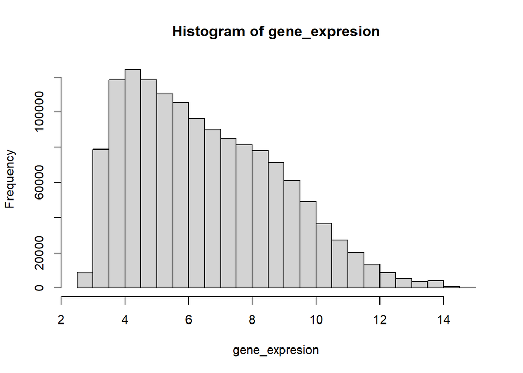

```r
hist(gene_expresion)
```

```r
print("As we can observe, the data needs to be normalized (applying logaritms)")
```

```
## [1] "As we can observe, the data needs to be normalized (applying logaritms)"
```

Normalizing the data

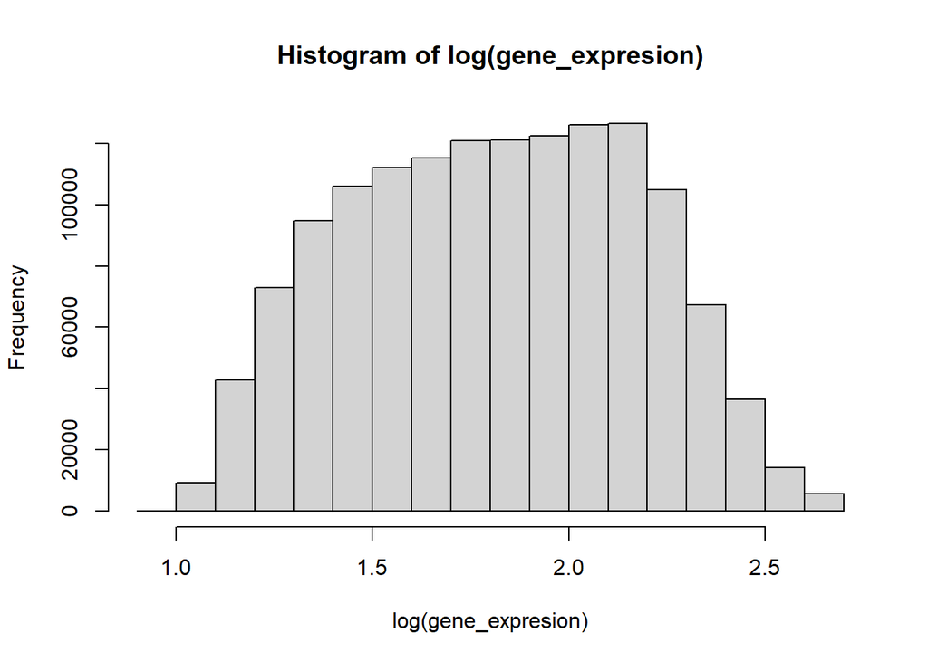

```r
hist(log(gene_expresion))
```

```r
print("The data looks better. So, we need to apply this transformation to the original data.")
```

```
## [1] "The data looks better. So, we need to apply this transformation to the original data."
```

```r
exprs(eset) <- log(exprs(eset))
```

Boxplots

```r
pcs <- prcomp(exprs(eset))
names(pcs)
```

```
## [1] "sdev"     "rotation" "center"   "scale"    "x"
```

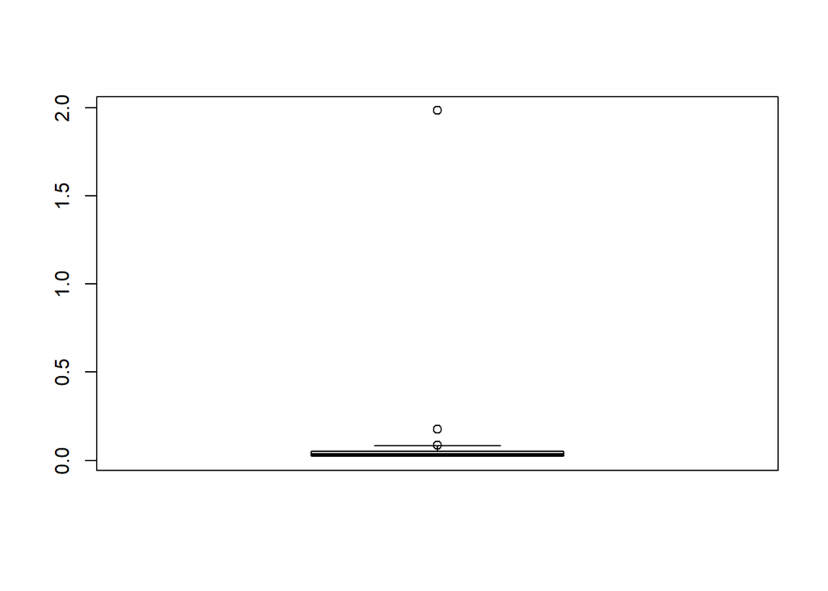

```r
boxplot(pcs$sdev)
```

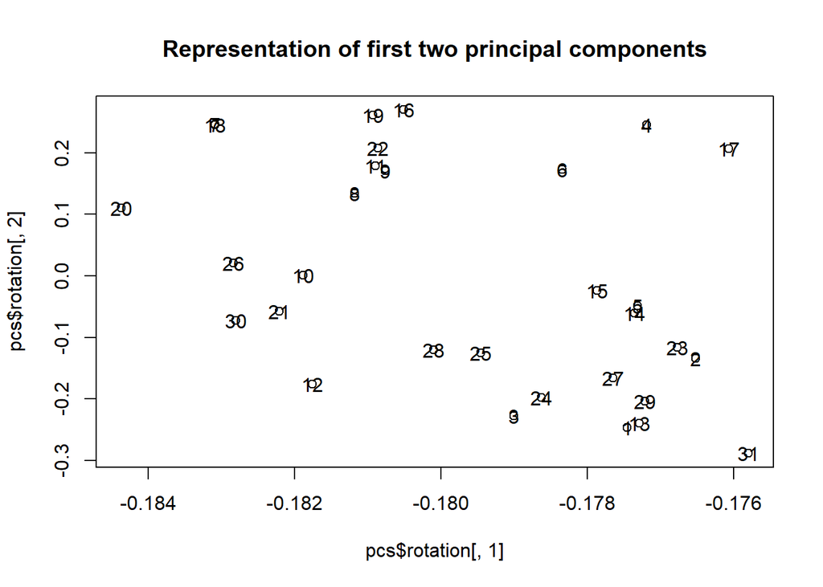

```r
plot(pcs$rotation[,1], pcs$rotation[,2], main="Representation of first two principal components")
text(pcs$rotation[,1], pcs$rotation[,2])
```

```r
print("To see the top variable genes")
```

```
## [1] "To see the top variable genes"
```

```r
genes <- rownames(gene_expresion)
variab <- apply(gene_expresion,1, sd)
orderedGenes <- genes[order(variab, decreasing=TRUE)]
head(variab[order(variab, decreasing=TRUE)])
```

```
##   1427801_at   1425431_at   1425655_at   1422588_at 1427549_s_at   1425430_at
##     3.066981     3.066118     3.025525     2.972325     2.921229     2.893752
```

Analyse the Top genes applying Barplots

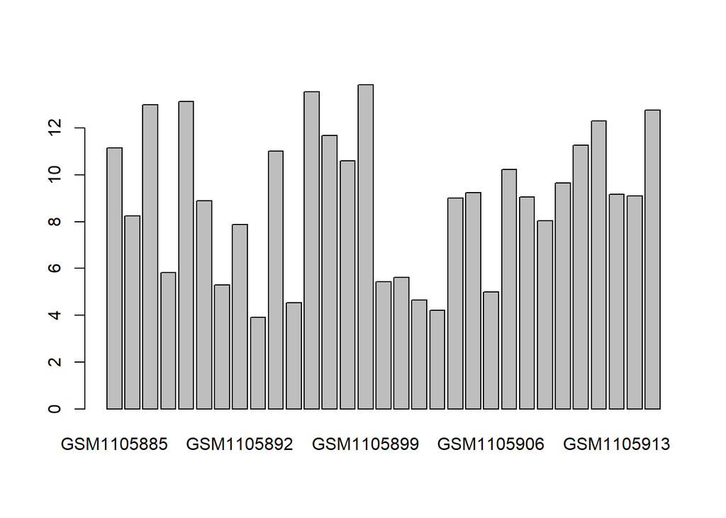

```r
# First Top gene
barplot(gene_expresion["1427801_at",])
```

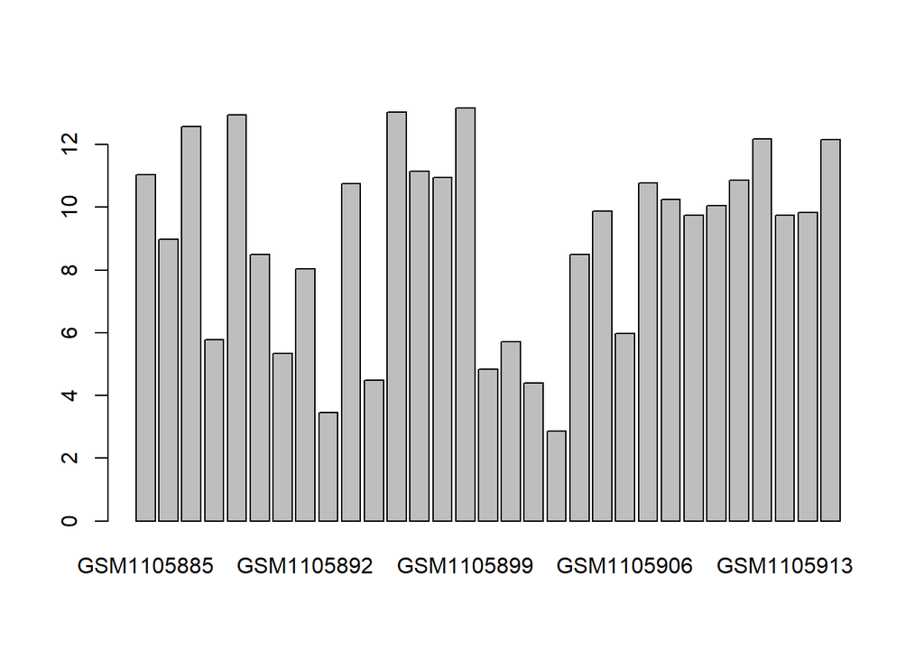

```r
# Second Top gene
barplot(gene_expresion["1425431_at",])
```

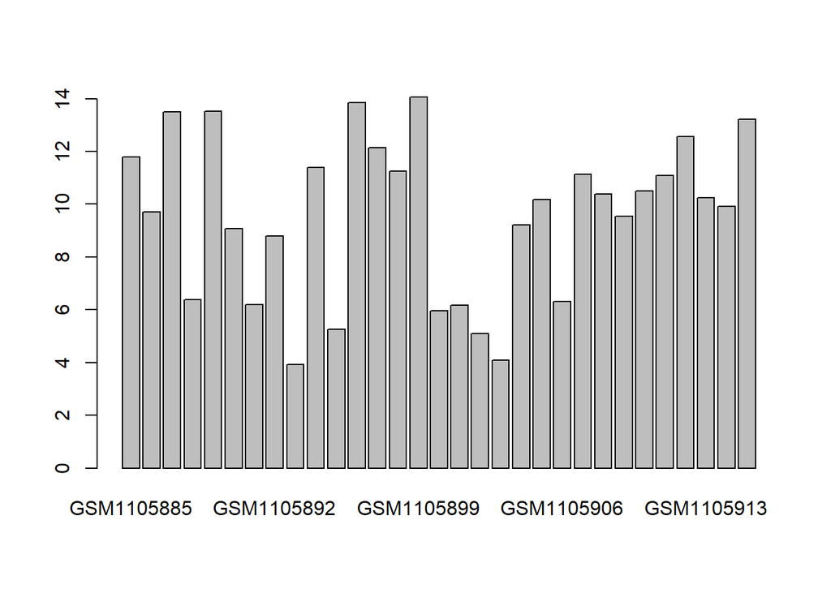

```r
# Third Top gene
barplot(gene_expresion["1425655_at",])
```

## Comparisions to be performed between groups

In our study, we have three groups after an alopecic graft transplantation, skin with treatment of ruxolitinib(jak1i), with treatment of tofacitinib(jak3i) or with a reference substance. Hence, our comparisions should be to compare group of jak1i to group jak3i and reference substance and jak3i to the reference substance. Question: How does affect the treatments after an alopecic graft transplant?

## Build the Design Matrix

```r
library(limma)
design_matrix <- matrix(
  c(1,1,1,1,1,1,1,1,1,1,1,0,0,0,0,0,0,0,0,0,0,0,0,0,0,0,0,0,0,0,0,
    0,0,0,0,0,0,0,0,0,0,0,1,1,1,1,1,1,1,1,1,1,1,0,0,0,0,0,0,0,0,0,
    0,0,0,0,0,0,0,0,0,0,0,0,0,0,0,0,0,0,0,0,0,0,1,1,1,1,1,1,1,1,1), nrow=31)
design2 <- model.matrix(~0+targets$`treatment:ch1`)
design2
```

```
##    targets$`treatment:ch1`jak1i targets$`treatment:ch1`jak3i
## 1                             1                            0
## 2                             1                            0
## 3                             1                            0
## 4                             1                            0
## 5                             1                            0
## 6                             1                            0
## 7                             1                            0
## 8                             1                            0
## 9                             1                            0
## 10                            1                            0
## 11                            1                            0
## 12                            0                            1
## 13                            0                            1
## 14                            0                            1
```

[output cut: 54 more lines]

```r
colnames(design_matrix)<- colnames(design2)<-c("jak1i", "jak3i", "PBS")
rownames(design_matrix) <- rownames(design2)<- targets$source_name_ch1

print(design_matrix); print(design2)
```

```
##                jak1i jak3i PBS
## skin-J1-0W-1       1     0   0
## skin-J1-0W-2       1     0   0
## skin-J1-0W-3       1     0   0
## skin-J1-6W-1       1     0   0
## skin-J1-6W-2       1     0   0
## skin-J1-6W-3       1     0   0
## skin-J1-12W-1      1     0   0
## skin-J1-12W-2      1     0   0
## skin-J1-12W-3      1     0   0
## skin-J1-24W-1      1     0   0
## skin-J1-24W-2      1     0   0
## skin-J3-0W-1       0     1   0
## skin-J3-0W-2       0     1   0
## skin-J3-0W-3       0     1   0
## skin-J3-6W-1       0     1   0
## skin-J3-6W-2       0     1   0
## skin-J3-6W-3       0     1   0
## skin-J3-12W-1      0     1   0
## skin-J3-12W-2      0     1   0
## skin-J3-12W-3      0     1   0
## skin-J3-24W-1      0     1   0
## skin-J3-24W-2      0     1   0
## skin-PBS-0W-1      0     0   1
## skin-PBS-0W-2      0     0   1
## skin-PBS-0W-3      0     0   1
## skin-PBS-6W-1      0     0   1
## skin-PBS-6W-2      0     0   1
## skin-PBS-6W-3      0     0   1
## skin-PBS-12W-1     0     0   1
## skin-PBS-12W-2     0     0   1
## skin-PBS-12W-3     0     0   1
```

```
##                jak1i jak3i PBS
## skin-J1-0W-1       1     0   0
## skin-J1-0W-2       1     0   0
## skin-J1-0W-3       1     0   0
## skin-J1-6W-1       1     0   0
## skin-J1-6W-2       1     0   0
## skin-J1-6W-3       1     0   0
## skin-J1-12W-1      1     0   0
## skin-J1-12W-2      1     0   0
## skin-J1-12W-3      1     0   0
## skin-J1-24W-1      1     0   0
## skin-J1-24W-2      1     0   0
## skin-J3-0W-1       0     1   0
## skin-J3-0W-2       0     1   0
## skin-J3-0W-3       0     1   0
## skin-J3-6W-1       0     1   0
## skin-J3-6W-2       0     1   0
## skin-J3-6W-3       0     1   0
## skin-J3-12W-1      0     1   0
## skin-J3-12W-2      0     1   0
## skin-J3-12W-3      0     1   0
## skin-J3-24W-1      0     1   0
## skin-J3-24W-2      0     1   0
## skin-PBS-0W-1      0     0   1
## skin-PBS-0W-2      0     0   1
## skin-PBS-0W-3      0     0   1
## skin-PBS-6W-1      0     0   1
## skin-PBS-6W-2      0     0   1
## skin-PBS-6W-3      0     0   1
## skin-PBS-12W-1     0     0   1
## skin-PBS-12W-2     0     0   1
## skin-PBS-12W-3     0     0   1
## attr(,"assign")
## [1] 1 1 1
## attr(,"contrasts")
## attr(,"contrasts")$`targets$`treatment:ch1``
## [1] "contr.treatment"
```

## Contrast Matrix

```r
contrast_matrix <- makeContrasts (
  Jak1ivsJak3i = jak3i-jak1i,
  Jak1ivsPBS = PBS-jak1i,
  Jak3ivsPBS = PBS-jak3i,
  levels=design_matrix)
contrast_matrix
```

```
##        Contrasts
## Levels  Jak1ivsJak3i Jak1ivsPBS Jak3ivsPBS
##   jak1i           -1         -1          0
##   jak3i            1          0         -1
##   PBS              0          1          1
```

# Diferential expressed genes selection

# Fit a linear Model

```r
dataMatrix <- gse[[1]]
colnames(dataMatrix)==rownames(targets)
```

```
##  [1] TRUE TRUE TRUE TRUE TRUE TRUE TRUE TRUE TRUE TRUE TRUE TRUE TRUE TRUE TRUE
## [16] TRUE TRUE TRUE TRUE TRUE TRUE TRUE TRUE TRUE TRUE TRUE TRUE TRUE TRUE TRUE
## [31] TRUE
```

```r
fit <- lmFit(dataMatrix, design_matrix)
fit_main <- contrasts.fit(fit, contrast_matrix)
fit_main <- eBayes(fit_main)
```

# Estimate Contrasts “TopTable”

```r
## Jak1i vs Jak3i
topTab_Jak1ivsJak3i <- topTable (fit_main, number=nrow(fit_main), coef="Jak1ivsJak3i", adjust="fdr"); head(topTab_Jak1ivsJak3i)
```

```
##                    ID    GB_ACC SPOT_ID Species.Scientific.Name Annotation.Date
## 1418344_at 1418344_at NM_021793      NA            Mus musculus     Oct 6, 2014
## 1451342_at 1451342_at  BC020531      NA            Mus musculus     Oct 6, 2014
## 1457346_at 1457346_at  BE649821      NA            Mus musculus     Oct 6, 2014
## 1445609_at 1445609_at  BE979533      NA            Mus musculus     Oct 6, 2014
## 1448977_at 1448977_at  BC003778      NA            Mus musculus     Oct 6, 2014
## 1451952_at 1451952_at  AF182065      NA            Mus musculus     Oct 6, 2014
##                 Sequence.Type Sequence.Source
## 1418344_at Consensus sequence         GenBank
## 1451342_at Consensus sequence         GenBank
## 1457346_at Consensus sequence         GenBank
## 1445609_at Consensus sequence         GenBank
## 1448977_at Consensus sequence         GenBank
## 1451952_at Consensus sequence         GenBank
##                                                                                                                                                                                                                                                                                                          …
## 1418344_at gb:NM_021793.1 /DB_XREF=gi:11140832 /GEN=Tmem8 /FEA=FLmRNA /CNT=65 /TID=Mm.143826.1 /TIER=FL+Stack /STK=25 /UG=Mm.143826 /LL=60455 /DEF=Mus musculus transmembrane protein 8 (five membrane-spanning domains) (Tmem8), mRNA. /PROD=transmembrane protein 8 (five membrane-spanningdomains) /FL…
## 1451342_at                                                                       gb:BC020531.1 /DB_XREF=gi:18088207 /FEA=FLmRNA /CNT=82 /TID=Mm.37938.1 /TIER=FL+Stack /STK=33 /UG=Mm.37938 /DEF=Mus musculus, Similar to spondin 1a, clone MGC:18859 IMAGE:4221758, mRNA, complete cds. /PROD=Similar to…
## 1457346_at                                                                                                                                       gb:BE649821 /DB_XREF=gi:9975645 /DB_XREF=UI-M-BH2.3-aqg-a-03-0-UI.r1 /CLONE=UI-M-BH2.3-aqg-a-03-0-UI /FEA=EST /CNT=6 /TID=Mm.65379.1 /TIER=ConsEnd /STK=…
## 1445609_at                                                                                                                                        gb:BE979533 /DB_XREF=gi:10646532 /DB_XREF=UI-M-BG2-bby-b-12-0-UI.s1 /CLONE=UI-M-BG2-bby-b-12-0-UI /FEA=EST /CNT=3 /TID=Mm.151090.1 /TIER=ConsEnd /STK=2…
## 1448977_at                 gb:BC003778.1 /DB_XREF=gi:13277770 /FEA=FLmRNA /CNT=78 /TID=Mm.3629.1 /TIER=FL /STK=2 /UG=Mm.3629 /LL=21420 /UG_GENE=Tcfap2c /DEF=Mus musculus, transcription factor AP-2, gamma, clone MGC:5992 IMAGE:3592762, mRNA, complete cds. /PROD=transcription factor AP-2, gamma /FL…
## 1451952_at                                                                                    gb:AF182065.1 /DB_XREF=gi:6524948 /GEN=Bv8 /FEA=FLmRNA /CNT=1 /TID=Mm.87365.3 /TIER=FL /STK=1 /UG=Mm.87365 /LL=50501 /DEF=Mus musculus Bv8 variant 2 precursor (Bv8) mRNA, complete cds. /PROD=Bv8 variant …
##            Representative.Public.ID
## 1418344_at                NM_021793
## 1451342_at                 BC020531
## 1457346_at                 BE649821
## 1445609_at                 BE979533
## 1448977_at                 BC003778
## 1451952_at                 AF182065
##                                                          Gene.Title Gene.Symbol
## 1418344_at transmembrane protein 8 (five membrane-spanning domains)       Tmem8
## 1451342_at      spondin 1, (f-spondin) extracellular matrix protein       Spon1
## 1457346_at
## 1445609_at
## 1448977_at                         transcription factor AP-2, gamma      Tfap2c
## 1451952_at                                           prokineticin 2       Prok2
##            ENTREZ_GENE_ID
## 1418344_at          60455
## 1451342_at         233744
## 1457346_at
## 1445609_at
```

[output cut: 22 more lines]

```
## 1451952_at                                                                                                                                                                                                                   0005576 // extracellular region // inferred from electronic annotation
##                                                                                                                                                                                                                                                                                                          …
## 1418344_at                                                                                                                                                                                                                                                                                               …
## 1451342_at
## 1457346_at
## 1445609_at
## 1448977_at 0000977 // RNA polymerase II regulatory region sequence-specific DNA binding // inferred from direct assay /// 0000980 // RNA polymerase II distal enhancer sequence-specific DNA binding // inferred from direct assay /// 0000981 // sequence-specific DNA binding RNA polymerase II transcr…
## 1451952_at                                                                                                                                                                                                                                                                                               …
##                 logFC  AveExpr         t      P.Value adj.P.Val         B
## 1418344_at  0.5391564 6.506461  4.093019 0.0002875059  0.999928 -1.103896
## 1451342_at  0.6354068 8.816449  3.712550 0.0008185807  0.999928 -1.648974
## 1457346_at -0.2260726 4.850038 -3.694965 0.0008586012  0.999928 -1.674101
## 1445609_at -0.1614512 3.949405 -3.694548 0.0008595727  0.999928 -1.674696
## 1448977_at -0.2178829 8.667912 -3.608191 0.0010856264  0.999928 -1.797904
## 1451952_at -0.1536714 3.440994 -3.475550 0.0015489149  0.999928 -1.986356
```

```r
## Jak1i vs PBS
topTab_Jak1ivsPBS <- topTable (fit_main, number=nrow(fit_main), coef="Jak1ivsPBS", adjust="fdr"); head(topTab_Jak1ivsPBS)
```

```
##                        ID   GB_ACC SPOT_ID Species.Scientific.Name
## 1423250_a_at 1423250_a_at BF144658      NA            Mus musculus
## 1439150_x_at 1439150_x_at BB480256      NA            Mus musculus
## 1425500_x_at 1425500_x_at BC003207      NA            Mus musculus
## 1439595_at     1439595_at BM243643      NA            Mus musculus
## 1443015_at     1443015_at BB208956      NA            Mus musculus
## 1422054_a_at 1422054_a_at   U36203      NA            Mus musculus
##              Annotation.Date      Sequence.Type Sequence.Source
## 1423250_a_at     Oct 6, 2014 Consensus sequence         GenBank
## 1439150_x_at     Oct 6, 2014 Consensus sequence         GenBank
## 1425500_x_at     Oct 6, 2014 Consensus sequence         GenBank
## 1439595_at       Oct 6, 2014 Consensus sequence         GenBank
## 1443015_at       Oct 6, 2014 Consensus sequence         GenBank
## 1422054_a_at     Oct 6, 2014 Consensus sequence         GenBank
##                                                                                                                                                                                                                                                Target.Description
## 1423250_a_at gb:AI323791 /DB_XREF=gi:4058220 /DB_XREF=mm47e08.x1 /CLONE=IMAGE:524678 /FEA=FLmRNA /CNT=136 /TID=Mm.18213.1 /TIER=Stack /STK=17 /UG=Mm.18213 /LL=21808 /UG_GENE=Tgfb2 /UG_TITLE=transforming growth factor, beta 2 /FL=gb:BC011170.1 gb:NM_009367.1
## 1439150_x_at                                                   gb:BB480256 /DB_XREF=gi:9397865 /DB_XREF=BB480256 /CLONE=D330045D12 /FEA=EST /CNT=11 /TID=Mm.34901.4 /TIER=Stack /STK=8 /UG=Mm.34901 /LL=66790 /UG_GENE=Grtp1 /UG_TITLE=GH regulated TBC protein 1
## 1425500_x_at                       gb:BC003207.1 /DB_XREF=gi:13096825 /FEA=FLmRNA /CNT=102 /TID=Mm.1232.2 /TIER=FL /STK=1 /UG=Mm.1232 /DEF=Mus musculus, clone MGC:8060 IMAGE:3587523, mRNA, complete cds. /PROD=Unknown (protein for MGC:8060) /FL=gb:BC003207.1
## 1439595_at                                                                                                gb:BM243643 /DB_XREF=gi:17878913 /DB_XREF=K0649G03-3 /CLONE=K0649G03 /FEA=EST /CNT=8 /TID=Mm.213248.1 /TIER=ConsEnd /STK=7 /UG=Mm.213248 /UG_TITLE=ESTs
## 1443015_at                                                                                                gb:BB208956 /DB_XREF=gi:16352399 /DB_XREF=BB208956 /CLONE=A430090F13 /FEA=EST /CNT=3 /TID=Mm.133765.1 /TIER=ConsEnd /STK=3 /UG=Mm.133765 /UG_TITLE=ESTs
## 1422054_a_at           gb:U36203.1 /DB_XREF=gi:1123024 /GEN=sno /FEA=FLmRNA /CNT=11 /TID=Mm.15406.1 /TIER=FL /STK=1 /UG=Mm.15406 /LL=20482 /DEF=Mus musculus snoN protein (sno) mRNA, complete cds. /PROD=snoN protein /FL=gb:U10532.1 gb:U36203.1 gb:NM_011386.1
##              Representative.Public.ID                         Gene.Title
## 1423250_a_at                 BF144658 transforming growth factor, beta 2
## 1439150_x_at                 BB480256         GH regulated TBC protein 1
## 1425500_x_at                 BC003207
## 1439595_at                   BM243643
## 1443015_at                   BB208956  ras homolog gene family, member H
## 1422054_a_at                   U36203                           SKI-like
##              Gene.Symbol ENTREZ_GENE_ID
## 1423250_a_at       Tgfb2          21808
## 1439150_x_at       Grtp1          66790
## 1425500_x_at
## 1439595_at
## 1443015_at          Rhoh          74734
## 1422054_a_at        Skil          20482
##                                                                                     RefSeq.Transcript.ID
## 1423250_a_at                                NM_009367 /// XM_006497135 /// XM_006497136 /// XM_006497137
## 1439150_x_at NM_025768 /// XM_006508850 /// XM_006508851 /// XM_006508852 /// XM_006508853 /// XR_378665
## 1425500_x_at
## 1439595_at
```

[output cut: 15 more lines]

```
## 1422054_a_at                                                                                                                                                                                                                                                                                             …
##                                                                                                                                                                                                                                                                                                          …
## 1423250_a_at 0001540 // beta-amyloid binding // not recorded /// 0004702 // receptor signaling protein serine/threonine kinase activity // not recorded /// 0005102 // receptor binding // not recorded /// 0005114 // type II transforming growth factor beta receptor binding // not recorded /// 00051…
## 1439150_x_at                                                                                                                                                                                                                                                                                             …
## 1425500_x_at
## 1439595_at
## 1443015_at                                                                                                                                                                                                                                                                                               …
## 1422054_a_at                                                                                                                                                                                                                                                              0000166 // nucleotide binding /…
##                   logFC  AveExpr         t      P.Value adj.P.Val        B
## 1423250_a_at -0.7051607 7.620630 -5.305044 9.316430e-06 0.2531673 2.802007
## 1439150_x_at -0.2507436 7.314584 -5.176163 1.345141e-05 0.2531673 2.521820
## 1425500_x_at  0.4536407 4.557252  5.000903 2.216347e-05 0.2531673 2.139123
## 1439595_at    1.1856793 6.161096  4.938385 2.648164e-05 0.2531673 2.002234
## 1443015_at    0.4426770 3.770515  4.710784 5.057256e-05 0.2531673 1.502777
## 1422054_a_at  0.8487174 5.631233  4.633111 6.303173e-05 0.2531673 1.332109
```

```r
## Jak3i vs PBS
topTab_Jak3ivsPBS  <- topTable (fit_main, number=nrow(fit_main) , coef="Jak3ivsPBS", adjust="fdr"); head(topTab_Jak3ivsPBS)
```

```
##                        ID   GB_ACC SPOT_ID Species.Scientific.Name
## 1459446_at     1459446_at BB524016      NA            Mus musculus
## 1426073_at     1426073_at AF292033      NA            Mus musculus
## 1441418_at     1441418_at BM240473      NA            Mus musculus
## 1456678_at     1456678_at AV314270      NA            Mus musculus
## 1425500_x_at 1425500_x_at BC003207      NA            Mus musculus
## 1439595_at     1439595_at BM243643      NA            Mus musculus
##              Annotation.Date      Sequence.Type Sequence.Source
## 1459446_at       Oct 6, 2014 Consensus sequence         GenBank
## 1426073_at       Oct 6, 2014 Consensus sequence         GenBank
## 1441418_at       Oct 6, 2014 Consensus sequence         GenBank
## 1456678_at       Oct 6, 2014 Consensus sequence         GenBank
## 1425500_x_at     Oct 6, 2014 Consensus sequence         GenBank
## 1439595_at       Oct 6, 2014 Consensus sequence         GenBank
##                                                                                                                                                                                                                                              Target.Description
## 1459446_at                                                                                              gb:BB524016 /DB_XREF=gi:16443915 /DB_XREF=BB524016 /CLONE=D930017K11 /FEA=EST /CNT=2 /TID=Mm.209717.1 /TIER=ConsEnd /STK=2 /UG=Mm.209717 /UG_TITLE=ESTs
## 1426073_at   gb:AF292033.1 /DB_XREF=gi:9837569 /GEN=Tsg /FEA=FLmRNA /CNT=1 /TID=Mm.10153.2 /TIER=FL /STK=1 /UG=Mm.10153 /LL=65960 /DEF=Mus musculus twisted gastrulation protein (Tsg) mRNA, complete cds. /PROD=twisted gastrulation protein /FL=gb:AF292033.1
## 1441418_at                                                                                              gb:BM240473 /DB_XREF=gi:17875743 /DB_XREF=K0602H08-3 /CLONE=K0602H08 /FEA=EST /CNT=4 /TID=Mm.215482.1 /TIER=ConsEnd /STK=4 /UG=Mm.215482 /UG_TITLE=ESTs
## 1456678_at                                                                                                gb:AV314270 /DB_XREF=gi:16394431 /DB_XREF=AV314270 /CLONE=5830417I11 /FEA=EST /CNT=9 /TID=Mm.133369.1 /TIER=Stack /STK=8 /UG=Mm.133369 /UG_TITLE=ESTs
## 1425500_x_at                     gb:BC003207.1 /DB_XREF=gi:13096825 /FEA=FLmRNA /CNT=102 /TID=Mm.1232.2 /TIER=FL /STK=1 /UG=Mm.1232 /DEF=Mus musculus, clone MGC:8060 IMAGE:3587523, mRNA, complete cds. /PROD=Unknown (protein for MGC:8060) /FL=gb:BC003207.1
## 1439595_at                                                                                              gb:BM243643 /DB_XREF=gi:17878913 /DB_XREF=K0649G03-3 /CLONE=K0649G03 /FEA=EST /CNT=8 /TID=Mm.213248.1 /TIER=ConsEnd /STK=7 /UG=Mm.213248 /UG_TITLE=ESTs
##              Representative.Public.ID
## 1459446_at                   BB524016
## 1426073_at                   AF292033
## 1441418_at                   BM240473
## 1456678_at                   AV314270
## 1425500_x_at                 BC003207
## 1439595_at                   BM243643
##                                               Gene.Title Gene.Symbol
## 1459446_at             leucine rich repeat containing 41      Lrrc41
## 1426073_at   twisted gastrulation homolog 1 (Drosophila)       Twsg1
## 1441418_at
## 1456678_at
## 1425500_x_at
## 1439595_at
##              ENTREZ_GENE_ID RefSeq.Transcript.ID
## 1459446_at           230654            NM_153521
## 1426073_at            65960            NM_023053
## 1441418_at
## 1456678_at
```

[output cut: 15 more lines]

```
## 1439595_at   0016020 // membrane // inferred from electronic annotation /// 0016021 // integral component of membrane // inferred from electronic annotation
##                                                                                                                             Gene.Ontology.Molecular.Function
## 1459446_at   0005515 // protein binding // inferred from physical interaction /// 0042803 // protein homodimerization activity // inferred from direct assay
## 1426073_at                                                                                  0005515 // protein binding // inferred from physical interaction
## 1441418_at
## 1456678_at
## 1425500_x_at
## 1439595_at
##                  logFC  AveExpr        t      P.Value  adj.P.Val        B
## 1459446_at   0.4593343 3.879049 5.525302 4.975371e-06 0.04953678 3.791653
## 1426073_at   0.4770856 5.523593 5.507840 5.228866e-06 0.04953678 3.749841
## 1441418_at   0.5889286 4.732155 5.432097 6.487199e-06 0.04953678 3.568246
## 1456678_at   0.7403507 4.563943 5.420532 6.704407e-06 0.04953678 3.540488
## 1425500_x_at 0.4910956 4.557252 5.413803 6.834140e-06 0.04953678 3.524332
## 1439595_at   1.2960977 6.161096 5.398281 7.143063e-06 0.04953678 3.487056
```